# R을 활용한 데이터분석_2

kimsungguen

2015년 11월 24일

## 1. 데이터 로딩

- 기본함수를 활용한데이터 핸들링
- 특정 그룹별로 통계량을 산출하는 방법 학습
- 네가지 고객그룹분류(케이블TV 마케팅 DATA)에 따른 통계량 산출
- NA값이 없는 클리닝이 완료된 데이터

```r
seg.df <- read.csv("http://goo.gl/qw303p")
head(seg.df)
```

```
##        age gender   income kids ownHome subscribe    Segment
## 1 47.31613   Male 49482.81    2   ownNo     subNo Suburb mix
## 2 31.38684   Male 35546.29    1  ownYes     subNo Suburb mix
## 3 43.20034   Male 44169.19    0  ownYes     subNo Suburb mix
## 4 37.31700 Female 81041.99    1   ownNo     subNo Suburb mix
## 5 40.95439 Female 79353.01    3  ownYes     subNo Suburb mix
## 6 43.03387   Male 58143.36    4  ownYes     subNo Suburb mix
```

```r
str(seg.df)
```

```
## 'data.frame':    300 obs. of  7 variables:
##  $ age      : num  47.3 31.4 43.2 37.3 41 ...
##  $ gender   : Factor w/ 2 levels "Female","Male": 2 2 2 1 1 2 2 2 1 1 ...
##  $ income   : num  49483 35546 44169 81042 79353 ...
##  $ kids     : int  2 1 0 1 3 4 3 0 1 0 ...
##  $ ownHome  : Factor w/ 2 levels "ownNo","ownYes": 1 2 2 1 2 2 1 1 1 2 ...
##  $ subscribe: Factor w/ 2 levels "subNo","subYes": 1 1 1 1 1 1 1 1 1 1 ...
##  $ Segment  : Factor w/ 4 levels "Moving up","Suburb mix",..: 2 2 2 2 2 2 2 2 2 2 ...
```

```r
summary(seg.df)
```

```
##       age           gender        income            kids        ownHome
##  Min.   :19.26   Female:157   Min.   : -5183   Min.   :0.00   ownNo :159
##  1st Qu.:33.01   Male  :143   1st Qu.: 39656   1st Qu.:0.00   ownYes:141
##  Median :39.49                Median : 52014   Median :1.00
##  Mean   :41.20                Mean   : 50937   Mean   :1.27
##  3rd Qu.:47.90                3rd Qu.: 61403   3rd Qu.:2.00
##  Max.   :80.49                Max.   :114278   Max.   :7.00
##   subscribe         Segment
##  subNo :260   Moving up : 70
##  subYes: 40   Suburb mix:100
##               Travelers : 80
##               Urban hip : 50
##
##
```

## 2. 그룹별 기술통계치 산출

- 특정 세그먼트 데이터 및 통계량 확인
- 소득과 케이블Tv구독은 관련이 있을까?
- 무빙업 그룹의 소득
- 무빙업 그룹 중 서비스 가입자와 비가입자 소득평균비교

```r
seg.df$income[seg.df$Segment == "Moving up"]
```

```
##  [1] 50595.78 50980.48 40590.08 52298.07 57663.86 56977.09 36411.98
##  [8] 46974.99 65233.26 58739.31 49509.43 57037.86 53792.40 69947.60
## [15] 57265.30 49895.18 52953.41 70541.50 66923.62 39678.95 54864.78
## [22] 60045.47 68037.81 73797.50 53604.17 52110.46 69549.93 50473.36
## [29] 61154.54 65688.53 49267.09 29771.91 51829.62 45637.09 53668.86
## [36] 43413.72 62087.12 49235.02 39779.99 41097.10 52776.42 58756.32
## [43] 44811.78 44125.40 36257.93 45347.01 50720.22 46540.88 50560.17
## [50] 59663.28 55940.78 66007.99 39366.95 54509.25 49308.97 54740.28
## [57] 49775.29 41766.29 73240.62 53520.36 66423.74 41192.28 58933.34
## [64] 52352.69 40522.39 43882.43 64197.09 47580.93 60747.34 53674.93
```

```r
mean(seg.df$income[seg.df$Segment == "Moving up"])
```

```
## [1] 53090.97
```

```r
mean(seg.df$income[seg.df$Segment == "Moving up" & seg.df$subscribe == "subNo"])
```

```
## [1] 53633.73
```

```r
mean(seg.df$income[seg.df$Segment == "Moving up" & seg.df$subscribe == "subYes"])
```

```
## [1] 50919.89
```

### 2.1 by 함수

- 특정 변수기준으로 기술 통계량 확인
- by함수는 결과값을 리스트로 출력해줌

```r
by(seg.df$income, seg.df$Segment, mean)
```

```
## seg.df$Segment: Moving up
## [1] 53090.97
## --------------------------------------------------------
## seg.df$Segment: Suburb mix
## [1] 55033.82
## --------------------------------------------------------
## seg.df$Segment: Travelers
## [1] 62213.94
## --------------------------------------------------------
## seg.df$Segment: Urban hip
## [1] 21681.93
```

```r
by(seg.df$income, list(seg.df$Segment, seg.df$subscribe), mean)
```

```
## : Moving up
## : subNo
## [1] 53633.73
## --------------------------------------------------------
## : Suburb mix
## : subNo
## [1] 54942.69
## --------------------------------------------------------
## : Travelers
## : subNo
## [1] 62746.11
## --------------------------------------------------------
## : Urban hip
## : subNo
## [1] 22082.11
## --------------------------------------------------------
## : Moving up
## : subYes
## [1] 50919.89
## --------------------------------------------------------
## : Suburb mix
## : subYes
## [1] 56461.41
## --------------------------------------------------------
## : Travelers
## : subYes
## [1] 58488.77
## --------------------------------------------------------
## : Urban hip
## : subYes
## [1] 20081.19
```

### 2.2 aggregate 함수

- aggregate 함수 사용하여 특정 변수기준으로 통계량 확인
- aggregate 함수는 기준이 되는 변수가 리스트여야함
- aggregate 함수는 결과값을 데이터프레임으로 출력해줌

```r
aggregate(seg.df$income, list(seg.df$Segment), mean)
```

```
##      Group.1        x
## 1  Moving up 53090.97
## 2 Suburb mix 55033.82
## 3  Travelers 62213.94
## 4  Urban hip 21681.93
```

```r
seg.income.mean <- aggregate(seg.df$income, list(seg.df$Segment), mean)
seg.income.mean
```

```
##      Group.1        x
## 1  Moving up 53090.97
## 2 Suburb mix 55033.82
## 3  Travelers 62213.94
## 4  Urban hip 21681.93
```

- 포뮬러 사용, 여러개의 변인을 고려한 비교를 할수 있음

```r
aggregate(income ~ Segment, data=seg.df, mean)
```

```
##      Segment   income
## 1  Moving up 53090.97
## 2 Suburb mix 55033.82
## 3  Travelers 62213.94
## 4  Urban hip 21681.93
```

```r
aggregate(income ~ Segment + ownHome, data = seg.df, mean)
```

```
##      Segment ownHome   income
## 1  Moving up   ownNo 54497.68
## 2 Suburb mix   ownNo 54932.83
## 3  Travelers   ownNo 63188.42
## 4  Urban hip   ownNo 21337.59
## 5  Moving up  ownYes 50216.37
## 6 Suburb mix  ownYes 55143.21
## 7  Travelers  ownYes 61889.12
## 8  Urban hip  ownYes 23059.27
```

```r
aggregate(income ~ Segment + ownHome + subscribe, data = seg.df, mean)
```

```
##       Segment ownHome subscribe   income
## 1   Moving up   ownNo     subNo 55402.89
## 2  Suburb mix   ownNo     subNo 54579.99
## 3   Travelers   ownNo     subNo 65852.54
## 4   Urban hip   ownNo     subNo 21604.16
## 5   Moving up  ownYes     subNo 49898.85
## 6  Suburb mix  ownYes     subNo 55354.86
## 7   Travelers  ownYes     subNo 61749.71
## 8   Urban hip  ownYes     subNo 23993.93
## 9   Moving up   ownNo    subYes 50675.70
## 10 Suburb mix   ownNo    subYes 63753.97
## 11  Travelers   ownNo    subYes 48091.75
## 12  Urban hip   ownNo    subYes 20271.33
## 13  Moving up  ownYes    subYes 51359.44
## 14 Suburb mix  ownYes    subYes 52815.13
## 15  Travelers  ownYes    subYes 62944.64
## 16  Urban hip  ownYes    subYes 19320.64
```

```r
agg.data <- aggregate(income ~ Segment + ownHome, data = seg.df, mean)
attributes(agg.data)
```

```
## $names
## [1] "Segment" "ownHome" "income"
##
## $row.names
## [1] 1 2 3 4 5 6 7 8
##
## $class
## [1] "data.frame"
```

### 2.3 table 함수

- 변인 및 변인 조합에 따라 빈도수를 파악할수 있음

```r
table(seg.df$Segment, seg.df$ownHome)
```

```
##
##              ownNo ownYes
##   Moving up     47     23
##   Suburb mix    52     48
##   Travelers     20     60
##   Urban hip     40     10
```

```r
table(seg.df$kids, seg.df$Segment)
```

```
##
##     Moving up Suburb mix Travelers Urban hip
##   0        13         11        80        17
##   1        17         36         0        17
##   2        18         22         0        11
##   3        13         19         0         4
##   4         5          7         0         1
##   5         3          3         0         0
##   6         0          2         0         0
##   7         1          0         0         0
```

- aggregate와 차이점

```r
aggregate(kids ~ Segment, data=seg.df, sum)
```

```
##      Segment kids
## 1  Moving up  134
## 2 Suburb mix  192
## 3  Travelers    0
## 4  Urban hip   55
```

## 3. 그룹별 통계량 시각화

### 3.1 명목형 변수의 시각화 - 세그먼트 기준으로 서비스이용 여부 시각화

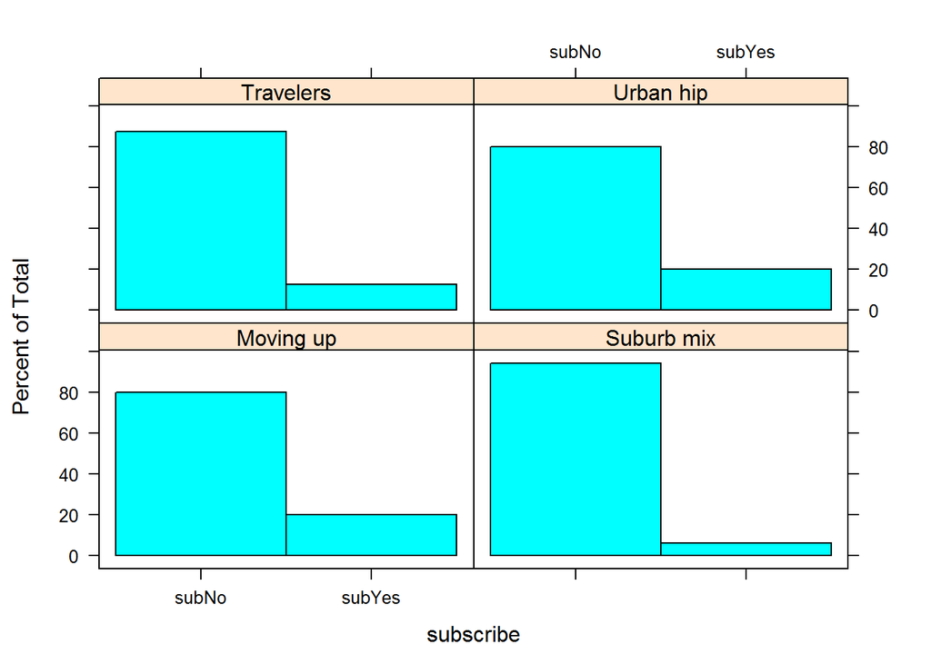

```r
library(lattice)
histogram(~subscribe | Segment, data = seg.df)
```

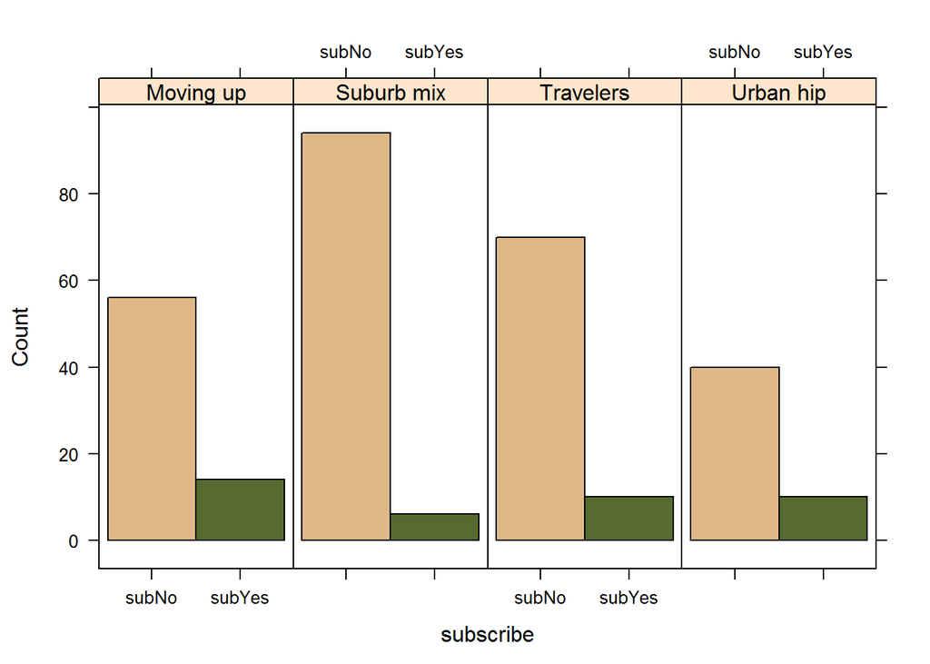

```r
histogram(~subscribe | Segment,
          data = seg.df,
          type="count",
          layout=c(4,1),
          col=c("burlywood", "darkolivegreen"))
```

- 세그먼트+자가여부 기준으로 서비스이용여부 시각화

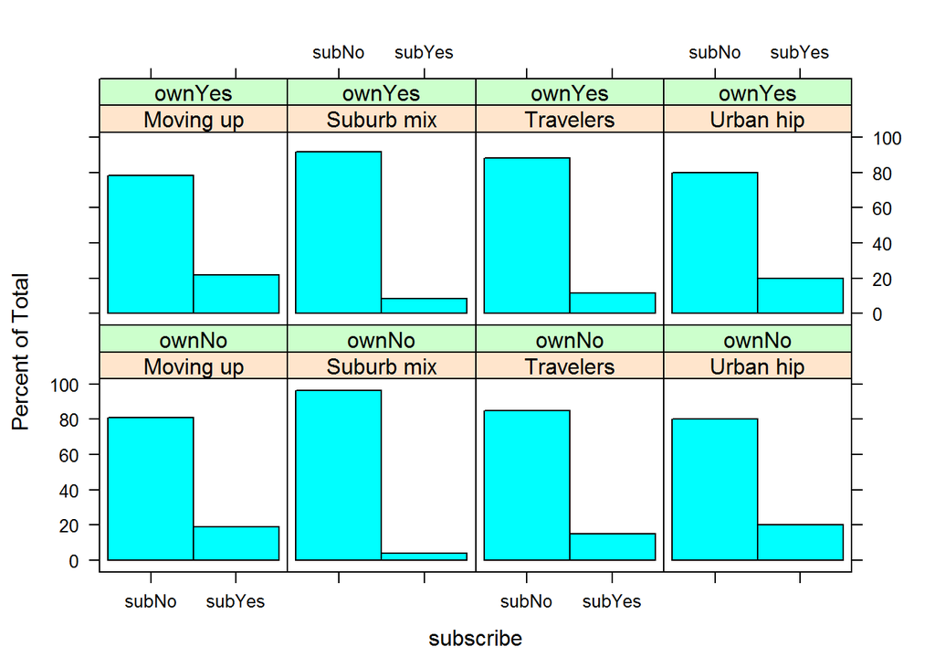

```r
histogram(~subscribe | Segment + ownHome, data=seg.df)
```

### 3.2 연속형(수치형)자료 시각화

- 세그먼트 기준으로 소득의 평균을 시각화

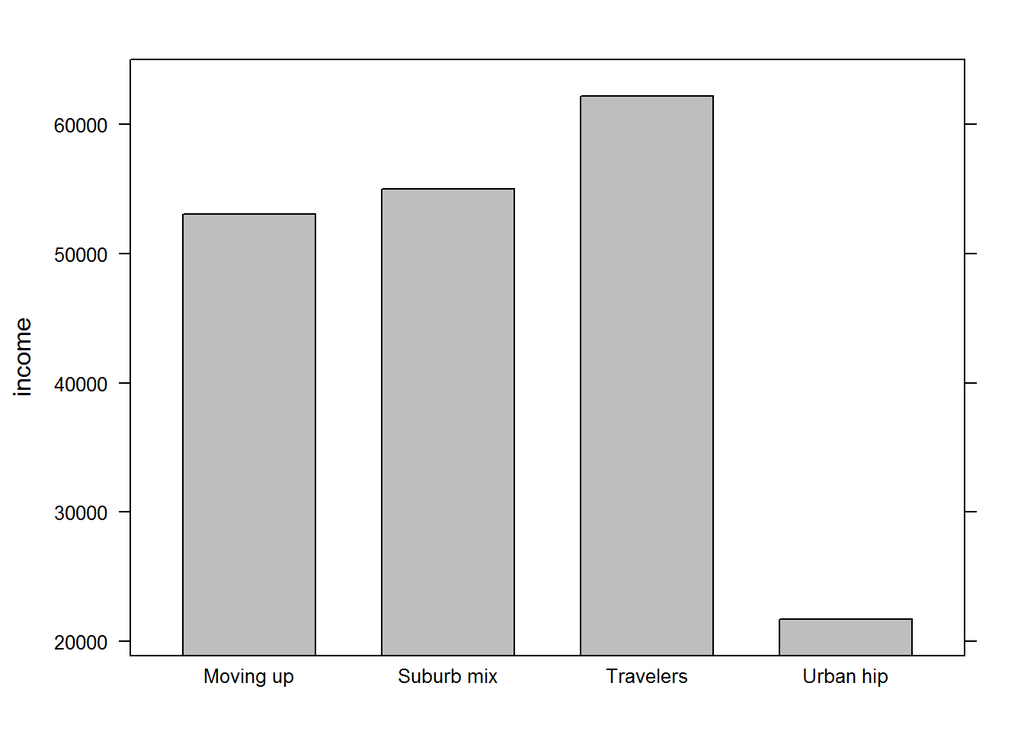

```r
seg.mean <- aggregate(income ~ Segment, data=seg.df, mean)

barchart(income~Segment,
         data = seg.mean,
         col="grey")
```

- 세그먼트별로 소득을 시각화(내부그룹=자가여부)

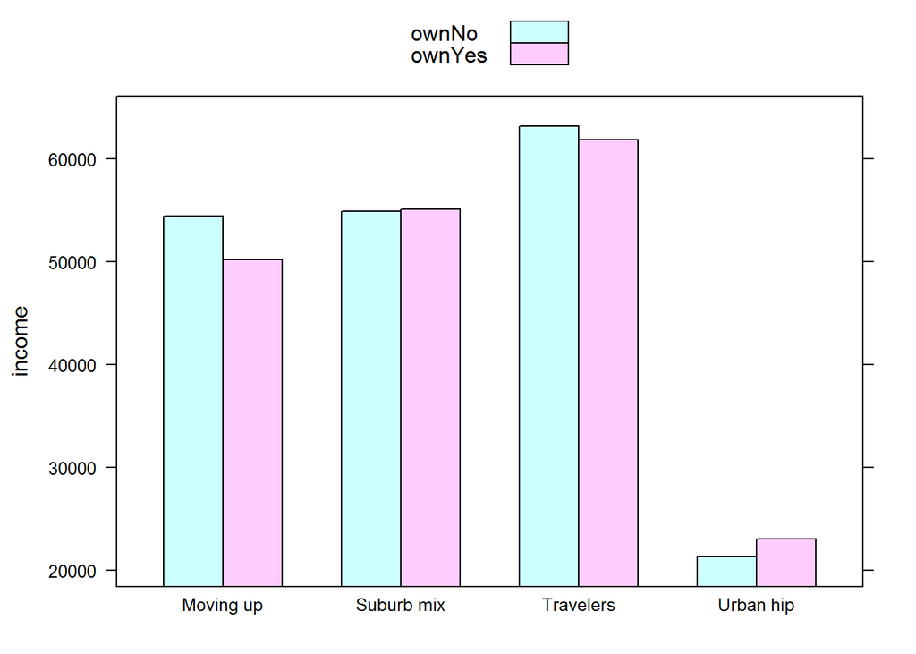

```r
seg.income.agg <- aggregate(income ~ Segment + ownHome,
                            data = seg.df, mean)

barchart(income ~ Segment,
         data=seg.income.agg,
         groups=ownHome, auto.key=TRUE,
         par.setting = simpleTheme(col=terrain.colors(2)))
```

## 4. dplyr 패키지로 데이터 다루기

### 4.1 데이터 확인

```r
library(dplyr)
library(hflights)
dim(hflights)
```

```
## [1] 227496     21
```

```r
head(hflights)
```

```
##      Year Month DayofMonth DayOfWeek DepTime ArrTime UniqueCarrier
## 5424 2011     1          1         6    1400    1500            AA
## 5425 2011     1          2         7    1401    1501            AA
## 5426 2011     1          3         1    1352    1502            AA
## 5427 2011     1          4         2    1403    1513            AA
## 5428 2011     1          5         3    1405    1507            AA
## 5429 2011     1          6         4    1359    1503            AA
##      FlightNum TailNum ActualElapsedTime AirTime ArrDelay DepDelay Origin
## 5424       428  N576AA                60      40      -10        0    IAH
## 5425       428  N557AA                60      45       -9        1    IAH
## 5426       428  N541AA                70      48       -8       -8    IAH
## 5427       428  N403AA                70      39        3        3    IAH
## 5428       428  N492AA                62      44       -3        5    IAH
## 5429       428  N262AA                64      45       -7       -1    IAH
##      Dest Distance TaxiIn TaxiOut Cancelled CancellationCode Diverted
## 5424  DFW      224      7      13         0                         0
## 5425  DFW      224      6       9         0                         0
## 5426  DFW      224      5      17         0                         0
## 5427  DFW      224      9      22         0                         0
## 5428  DFW      224      9       9         0                         0
## 5429  DFW      224      6      13         0                         0
```

```r
hflights_df<-tbl_df(hflights)
hflights_df
```

```
## Source: local data frame [227,496 x 21]
##
##    Year Month DayofMonth DayOfWeek DepTime ArrTime UniqueCarrier FlightNum
## 1  2011     1          1         6    1400    1500            AA       428
## 2  2011     1          2         7    1401    1501            AA       428
## 3  2011     1          3         1    1352    1502            AA       428
## 4  2011     1          4         2    1403    1513            AA       428
## 5  2011     1          5         3    1405    1507            AA       428
## 6  2011     1          6         4    1359    1503            AA       428
## 7  2011     1          7         5    1359    1509            AA       428
## 8  2011     1          8         6    1355    1454            AA       428
## 9  2011     1          9         7    1443    1554            AA       428
## 10 2011     1         10         1    1443    1553            AA       428
## ..  ...   ...        ...       ...     ...     ...           ...       ...
## Variables not shown: TailNum (chr), ActualElapsedTime (int), AirTime
##   (int), ArrDelay (int), DepDelay (int), Origin (chr), Dest (chr),
##   Distance (int), TaxiIn (int), TaxiOut (int), Cancelled (int),
##   CancellationCode (chr), Diverted (int)
```

### 4.2 dplyr패키지를 활용한 데이터 핸들링

- filter함수 : AND조건문은 (콤마) 또는 &, OR조건문은 |
- 1,2월 데이터만 추출하기

```r
filter(hflights_df, Month==1, DayofMonth==1)
```

```
## Source: local data frame [552 x 21]
##
##    Year Month DayofMonth DayOfWeek DepTime ArrTime UniqueCarrier FlightNum
## 1  2011     1          1         6    1400    1500            AA       428
## 2  2011     1          1         6     728     840            AA       460
## 3  2011     1          1         6    1631    1736            AA      1121
## 4  2011     1          1         6    1756    2112            AA      1294
## 5  2011     1          1         6    1012    1347            AA      1700
## 6  2011     1          1         6    1211    1325            AA      1820
## 7  2011     1          1         6     557     906            AA      1994
## 8  2011     1          1         6    1824    2106            AS       731
## 9  2011     1          1         6     654    1124            B6       620
## 10 2011     1          1         6    1639    2110            B6       622
## ..  ...   ...        ...       ...     ...     ...           ...       ...
## Variables not shown: TailNum (chr), ActualElapsedTime (int), AirTime
##   (int), ArrDelay (int), DepDelay (int), Origin (chr), Dest (chr),
##   Distance (int), TaxiIn (int), TaxiOut (int), Cancelled (int),
##   CancellationCode (chr), Diverted (int)
```

```r
filter(hflights_df, Month==1 | Month==2)
```

```
## Source: local data frame [36,038 x 21]
##
##    Year Month DayofMonth DayOfWeek DepTime ArrTime UniqueCarrier FlightNum
## 1  2011     1          1         6    1400    1500            AA       428
## 2  2011     1          2         7    1401    1501            AA       428
## 3  2011     1          3         1    1352    1502            AA       428
## 4  2011     1          4         2    1403    1513            AA       428
## 5  2011     1          5         3    1405    1507            AA       428
## 6  2011     1          6         4    1359    1503            AA       428
## 7  2011     1          7         5    1359    1509            AA       428
## 8  2011     1          8         6    1355    1454            AA       428
## 9  2011     1          9         7    1443    1554            AA       428
## 10 2011     1         10         1    1443    1553            AA       428
## ..  ...   ...        ...       ...     ...     ...           ...       ...
## Variables not shown: TailNum (chr), ActualElapsedTime (int), AirTime
##   (int), ArrDelay (int), DepDelay (int), Origin (chr), Dest (chr),
##   Distance (int), TaxiIn (int), TaxiOut (int), Cancelled (int),
##   CancellationCode (chr), Diverted (int)
```

- arrange함수 : 데이터 정렬(내림차순은 desc인수)

```r
arrange(hflights_df, ArrDelay, Month, Year)
```

```
## Source: local data frame [227,496 x 21]
##
##    Year Month DayofMonth DayOfWeek DepTime ArrTime UniqueCarrier FlightNum
## 1  2011     7          3         7    1914    2039            XE      2804
## 2  2011    12         25         7     741     926            OO      4591
## 3  2011     8         21         7     935    1039            OO      2001
## 4  2011     8         31         3     934    1039            OO      2040
## 5  2011     8         26         5    2107    2205            OO      2003
## 6  2011    12         24         6    2129    2337            CO      1552
## 7  2011     8         28         7    2059    2206            OO      2003
## 8  2011     8         29         1     935    1041            OO      2040
## 9  2011     8         18         4     939    1043            OO      2001
## 10 2011    12         24         6    2117    2258            CO      1712
## ..  ...   ...        ...       ...     ...     ...           ...       ...
## Variables not shown: TailNum (chr), ActualElapsedTime (int), AirTime
##   (int), ArrDelay (int), DepDelay (int), Origin (chr), Dest (chr),
##   Distance (int), TaxiIn (int), TaxiOut (int), Cancelled (int),
##   CancellationCode (chr), Diverted (int)
```

```r
arrange(hflights_df, desc(Month))
```

```
## Source: local data frame [227,496 x 21]
##
##    Year Month DayofMonth DayOfWeek DepTime ArrTime UniqueCarrier FlightNum
## 1  2011    12         15         4    2113    2217            AA       426
## 2  2011    12         16         5    2004    2128            AA       426
## 3  2011    12         18         7    2007    2113            AA       426
## 4  2011    12         19         1    2108    2223            AA       426
## 5  2011    12         20         2    2008    2107            AA       426
## 6  2011    12         21         3    2025    2124            AA       426
## 7  2011    12         22         4    2021    2118            AA       426
## 8  2011    12         23         5    2015    2118            AA       426
## 9  2011    12         26         1    2013    2118            AA       426
## 10 2011    12         27         2    2007    2123            AA       426
## ..  ...   ...        ...       ...     ...     ...           ...       ...
## Variables not shown: TailNum (chr), ActualElapsedTime (int), AirTime
##   (int), ArrDelay (int), DepDelay (int), Origin (chr), Dest (chr),
##   Distance (int), TaxiIn (int), TaxiOut (int), Cancelled (int),
##   CancellationCode (chr), Diverted (int)
```

- select함수 : 데이터 컬럼추출
- 여러개 collumn 추출시 (,)콤마, (:)콜론,(-)마이너스활용
- mutate함수 : 데이터를 변이시킴

```r
select(hflights_df, Year, Month, DayOfWeek)
```

```
## Source: local data frame [227,496 x 3]
##
##    Year Month DayOfWeek
## 1  2011     1         6
## 2  2011     1         7
## 3  2011     1         1
## 4  2011     1         2
## 5  2011     1         3
## 6  2011     1         4
## 7  2011     1         5
## 8  2011     1         6
## 9  2011     1         7
## 10 2011     1         1
## ..  ...   ...       ...
```

```r
select(hflights_df, Year:DayOfWeek)
```

```
## Source: local data frame [227,496 x 4]
##
##    Year Month DayofMonth DayOfWeek
## 1  2011     1          1         6
## 2  2011     1          2         7
## 3  2011     1          3         1
## 4  2011     1          4         2
## 5  2011     1          5         3
## 6  2011     1          6         4
## 7  2011     1          7         5
## 8  2011     1          8         6
## 9  2011     1          9         7
## 10 2011     1         10         1
## ..  ...   ...        ...       ...
```

```r
select(hflights_df, -(Year:DayOfWeek))
```

```
## Source: local data frame [227,496 x 17]
##
##    DepTime ArrTime UniqueCarrier FlightNum TailNum ActualElapsedTime
## 1     1400    1500            AA       428  N576AA                60
## 2     1401    1501            AA       428  N557AA                60
## 3     1352    1502            AA       428  N541AA                70
## 4     1403    1513            AA       428  N403AA                70
## 5     1405    1507            AA       428  N492AA                62
## 6     1359    1503            AA       428  N262AA                64
## 7     1359    1509            AA       428  N493AA                70
## 8     1355    1454            AA       428  N477AA                59
## 9     1443    1554            AA       428  N476AA                71
## 10    1443    1553            AA       428  N504AA                70
## ..     ...     ...           ...       ...     ...               ...
## Variables not shown: AirTime (int), ArrDelay (int), DepDelay (int), Origin
##   (chr), Dest (chr), Distance (int), TaxiIn (int), TaxiOut (int),
##   Cancelled (int), CancellationCode (chr), Diverted (int)
```

- mutate함수 : 기존데이터를 활용해 새로운 컬럼 추가

```r
mutate(hflights_df, gain=ArrDelay-DepDelay, gain_per_hour=gain/(AirTime/60))
```

```
## Source: local data frame [227,496 x 23]
##
##    Year Month DayofMonth DayOfWeek DepTime ArrTime UniqueCarrier FlightNum
## 1  2011     1          1         6    1400    1500            AA       428
## 2  2011     1          2         7    1401    1501            AA       428
## 3  2011     1          3         1    1352    1502            AA       428
## 4  2011     1          4         2    1403    1513            AA       428
## 5  2011     1          5         3    1405    1507            AA       428
## 6  2011     1          6         4    1359    1503            AA       428
## 7  2011     1          7         5    1359    1509            AA       428
## 8  2011     1          8         6    1355    1454            AA       428
## 9  2011     1          9         7    1443    1554            AA       428
## 10 2011     1         10         1    1443    1553            AA       428
## ..  ...   ...        ...       ...     ...     ...           ...       ...
## Variables not shown: TailNum (chr), ActualElapsedTime (int), AirTime
##   (int), ArrDelay (int), DepDelay (int), Origin (chr), Dest (chr),
##   Distance (int), TaxiIn (int), TaxiOut (int), Cancelled (int),
##   CancellationCode (chr), Diverted (int), gain (int), gain_per_hour (dbl)
```

- 평균지연시간 계산 (spldf보다 간편)

```r
summarise(hflights_df, delay=mean(DepDelay, na.rm=TRUE))
```

```
## Source: local data frame [1 x 1]
##
##      delay
## 1 9.444951
```

```r
planes<-group_by(hflights_df, TailNum)
delay<-summarise(planes,
                 count=n(),
                 dist=mean(Distance, na.rm=TRUE),
                 delay=mean(ArrDelay,na.rm=TRUE))
delay
```

```
## Source: local data frame [3,320 x 4]
##
##    TailNum count      dist     delay
## 1            795  938.7157       NaN
## 2   N0EGMQ    40 1095.2500  1.918919
## 3   N10156   317  801.7192  8.199357
## 4   N10575    94  631.5319 18.148936
## 5   N11106   308  774.9805 10.101639
## 6   N11107   345  768.1130  8.052786
## 7   N11109   331  772.4532 10.280000
## 8   N11113   282  772.8298  4.057143
## 9   N11119   130  790.2385  7.396825
## 10  N11121   333  774.8018  6.740854
## ..     ...   ...       ...       ...
```

```r
delay<-filter(delay, count>20, dist<2000)
delay
```

```
## Source: local data frame [1,526 x 4]
##
##    TailNum count      dist     delay
## 1            795  938.7157       NaN
## 2   N0EGMQ    40 1095.2500  1.918919
## 3   N10156   317  801.7192  8.199357
## 4   N10575    94  631.5319 18.148936
## 5   N11106   308  774.9805 10.101639
## 6   N11107   345  768.1130  8.052786
## 7   N11109   331  772.4532 10.280000
## 8   N11113   282  772.8298  4.057143
## 9   N11119   130  790.2385  7.396825
## 10  N11121   333  774.8018  6.740854
## ..     ...   ...       ...       ...
```

- ggplot 그리기

```
## geom_smooth: method="auto" and size of largest group is >=1000, so using gam with formula: y ~ s(x, bs = "cs"). Use 'method = x' to change the smoothing method.
```

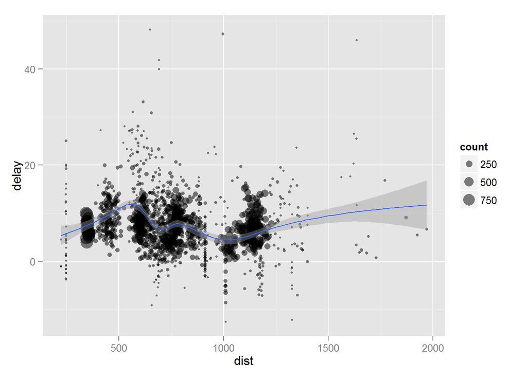

```r
library(ggplot2)
delayplot<-ggplot(delay, aes(dist,delay))
delayplot2<-delayplot+geom_point(aes(size=count),alpha=1/2)
delayplot3<-delayplot2+geom_smooth()+scale_size_area()
delayplot3
```

## 5. 회귀분석

- 데이터 로딩: 놀이공원 만족도 조사 데이터
- 주말여부/아이숫자/거리/놀이기구/게임/대기시간/청결/전체만족도

```r
sat.df <- read.csv("http://goo.gl/HKnl74")
str(sat.df)
```

```
## 'data.frame':    500 obs. of  8 variables:
##  $ weekend  : Factor w/ 2 levels "no","yes": 2 2 1 2 1 1 2 1 1 2 ...
##  $ num.child: int  0 2 1 0 4 5 1 0 0 3 ...
##  $ distance : num  114.6 27 63.3 25.9 54.7 ...
##  $ rides    : int  87 87 85 88 84 81 77 82 90 88 ...
##  $ games    : int  73 78 80 72 87 79 73 70 88 86 ...
##  $ wait     : int  60 76 70 66 74 48 58 70 79 55 ...
##  $ clean    : int  89 87 88 89 87 79 85 83 95 88 ...
##  $ overall  : int  47 65 61 37 68 27 40 30 58 36 ...
```

```r
summary(sat.df)
```

```
##  weekend     num.child        distance            rides
##  no :259   Min.   :0.000   Min.   :  0.5267   Min.   : 72.00
##  yes:241   1st Qu.:0.000   1st Qu.: 10.3181   1st Qu.: 82.00
##            Median :2.000   Median : 19.0191   Median : 86.00
##            Mean   :1.738   Mean   : 31.0475   Mean   : 85.85
##            3rd Qu.:3.000   3rd Qu.: 39.5821   3rd Qu.: 90.00
##            Max.   :5.000   Max.   :239.1921   Max.   :100.00
##      games             wait           clean          overall
##  Min.   : 57.00   Min.   : 40.0   Min.   : 74.0   Min.   :  6.00
##  1st Qu.: 73.00   1st Qu.: 62.0   1st Qu.: 84.0   1st Qu.: 40.00
##  Median : 78.00   Median : 70.0   Median : 88.0   Median : 50.00
##  Mean   : 78.67   Mean   : 69.9   Mean   : 87.9   Mean   : 51.26
##  3rd Qu.: 85.00   3rd Qu.: 77.0   3rd Qu.: 91.0   3rd Qu.: 62.00
##  Max.   :100.00   Max.   :100.0   Max.   :100.0   Max.   :100.00
```

- 데이터분포 탐색
- 편포된 변인(거리) 로그함

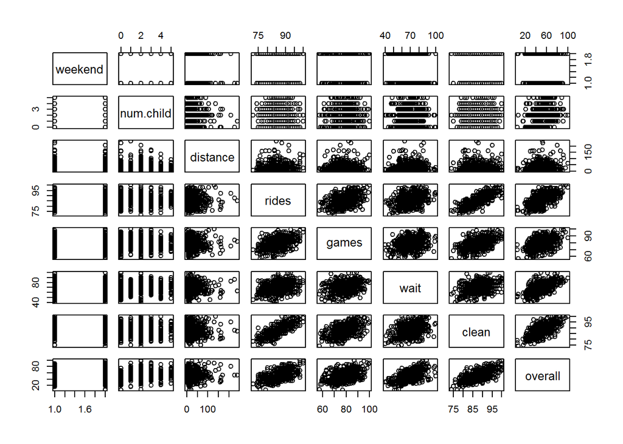

```r
pairs(sat.df)
```

```r
sat.df$logdist <- log(sat.df$distance)
```

- 단변량 회귀분석

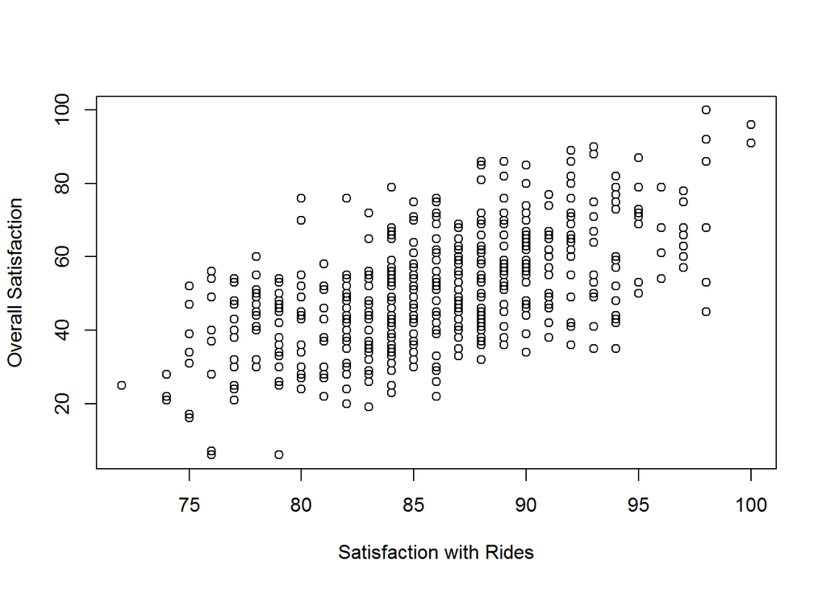

```r
plot(overall~rides, data=sat.df,
     xlab="Satisfaction with Rides",
     ylab="Overall Satisfaction")
```

```r
lm1 = lm(overall ~ rides, data=sat.df)
summary(lm1)
```

```
##
## Call:
## lm(formula = overall ~ rides, data = sat.df)
##
## Residuals:
##     Min      1Q  Median      3Q     Max
## -33.597 -10.048   0.425   8.694  34.699
##
## Coefficients:
##             Estimate Std. Error t value Pr(>|t|)
## (Intercept) -94.9622     9.0790  -10.46   <2e-16 ***
## rides         1.7033     0.1055   16.14   <2e-16 ***
## ---
## Signif. codes:  0 '***' 0.001 '**' 0.01 '*' 0.05 '.' 0.1 ' ' 1
##
## Residual standard error: 12.88 on 498 degrees of freedom
## Multiple R-squared:  0.3434, Adjusted R-squared:  0.3421
## F-statistic: 260.4 on 1 and 498 DF,  p-value: < 2.2e-16
```

```r
lm1$coefficients
```

```
## (Intercept)       rides
##  -94.962246    1.703285
```

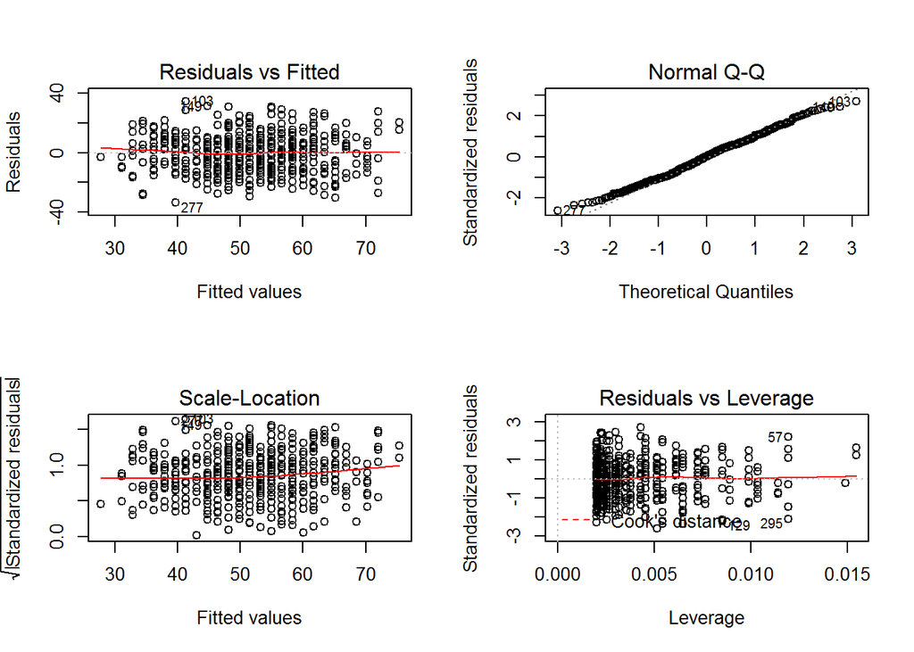

```r
par(mfrow=c(2,2))
plot(lm1)
```

- 다변량 회귀분석

```r
lm2 = lm(overall ~ rides + games + wait + clean, data=sat.df)
summary(lm2)
```

```
##
## Call:
## lm(formula = overall ~ rides + games + wait + clean, data = sat.df)
##
## Residuals:
##     Min      1Q  Median      3Q     Max
## -29.944  -6.841   1.072   7.167  28.618
##
## Coefficients:
##               Estimate Std. Error t value Pr(>|t|)
## (Intercept) -131.40919    8.33377 -15.768  < 2e-16 ***
## rides          0.52908    0.14207   3.724 0.000219 ***
## games          0.15334    0.06908   2.220 0.026903 *
## wait           0.55333    0.04781  11.573  < 2e-16 ***
## clean          0.98421    0.15987   6.156 1.54e-09 ***
## ---
## Signif. codes:  0 '***' 0.001 '**' 0.01 '*' 0.05 '.' 0.1 ' ' 1
##
## Residual standard error: 10.59 on 495 degrees of freedom
## Multiple R-squared:  0.5586, Adjusted R-squared:  0.5551
## F-statistic: 156.6 on 4 and 495 DF,  p-value: < 2.2e-16
```

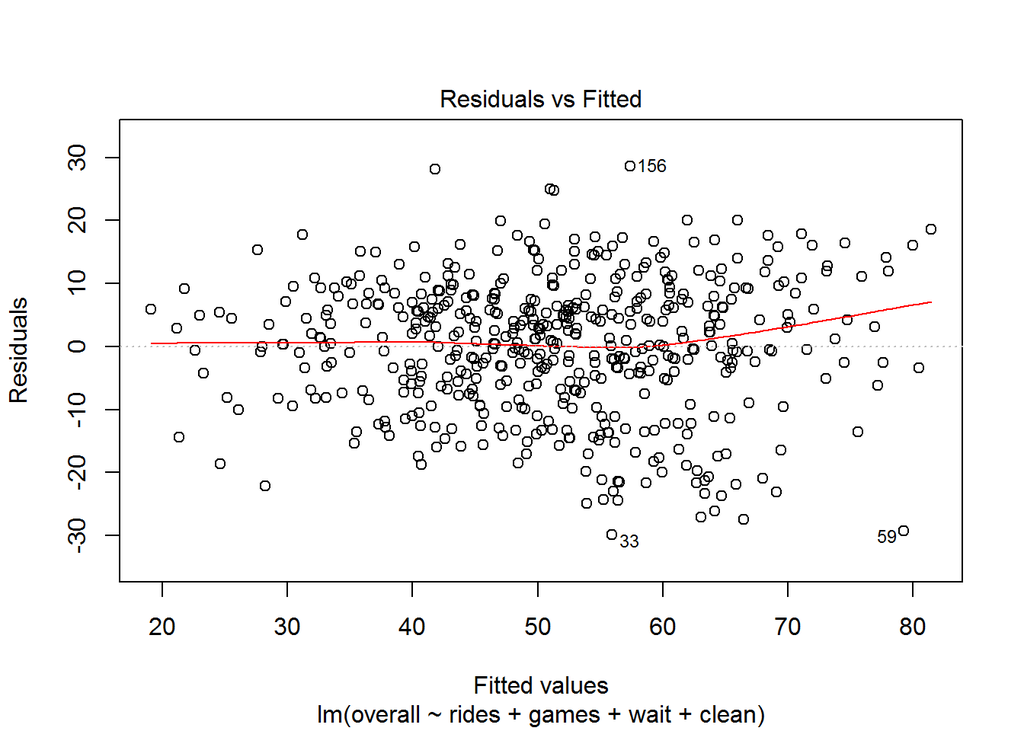

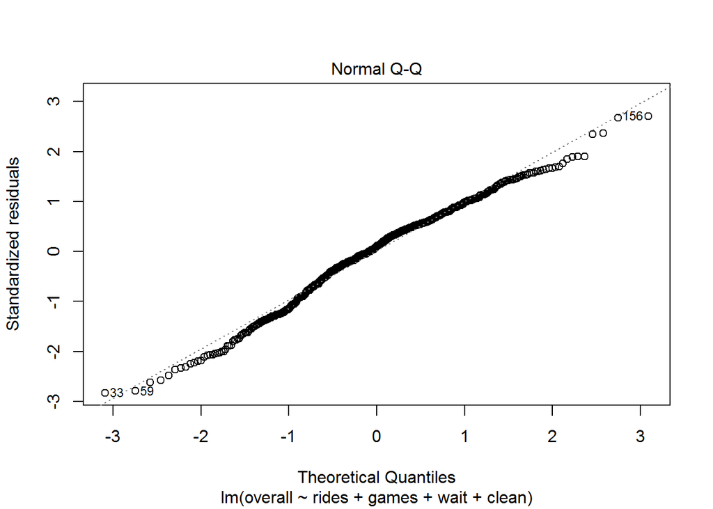

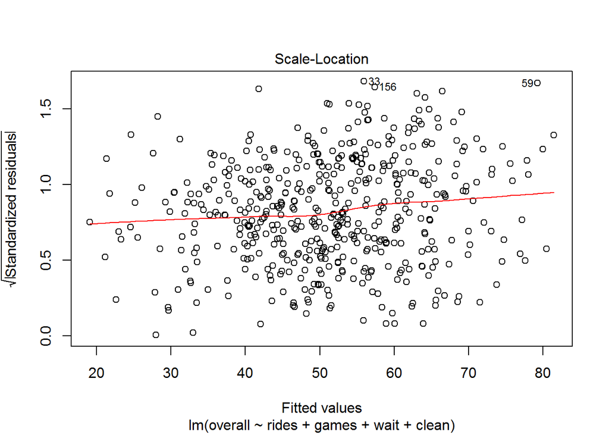

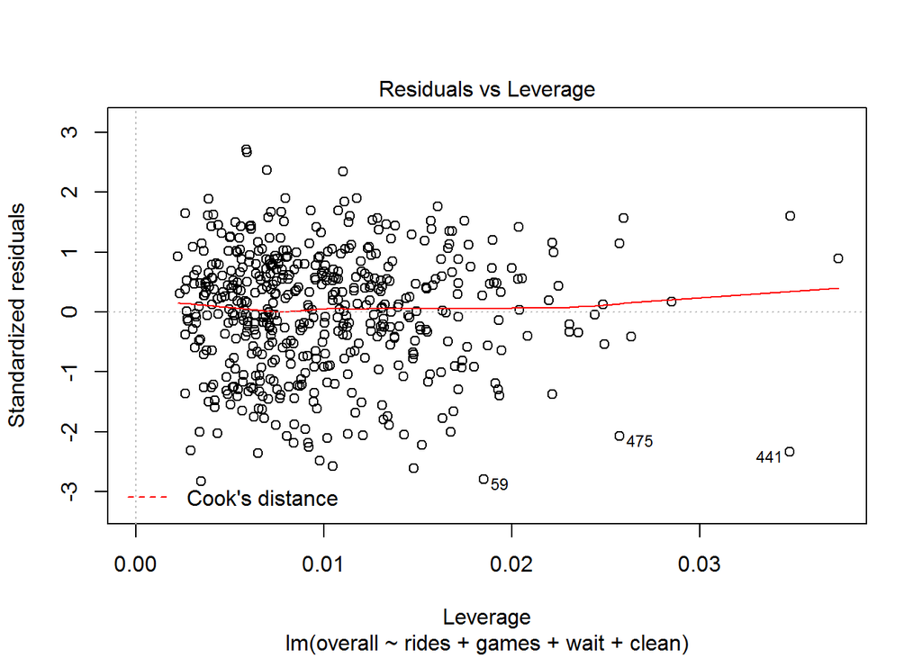

```r
plot(lm2)
```

- 변인들간의 상호작용을 확인하는 방법

```r
lm3 = lm(overall ~ rides*games, data=sat.df)
summary(lm3)
```

```
##
## Call:
## lm(formula = overall ~ rides * games, data = sat.df)
##
## Residuals:
##     Min      1Q  Median      3Q     Max
## -32.200  -9.356  -0.313   8.927  32.936
##
## Coefficients:
##               Estimate Std. Error t value Pr(>|t|)
## (Intercept) -56.011520  82.387884  -0.680    0.497
## rides         0.861823   0.964334   0.894    0.372
## games        -0.181435   1.039219  -0.175    0.861
## rides:games   0.007021   0.012079   0.581    0.561
##
## Residual standard error: 12.53 on 496 degrees of freedom
## Multiple R-squared:  0.3806, Adjusted R-squared:  0.3768
## F-statistic: 101.6 on 3 and 496 DF,  p-value: < 2.2e-16
```

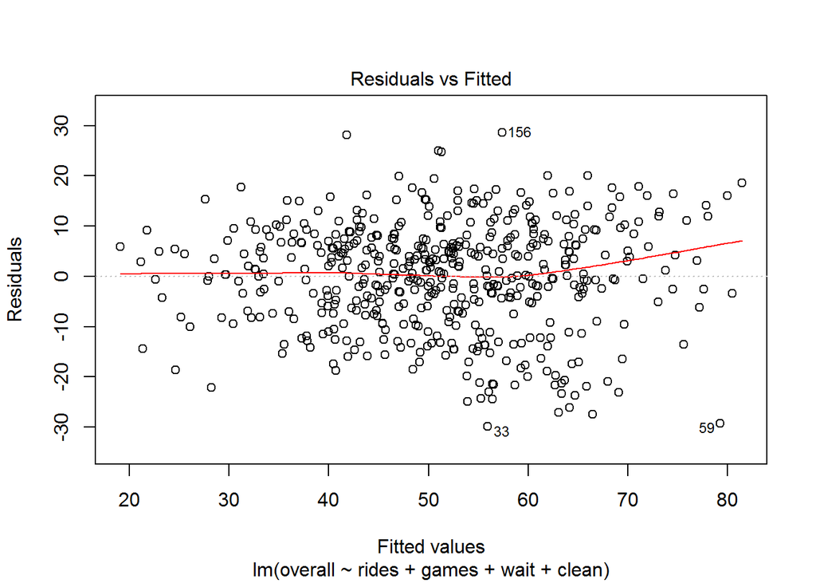

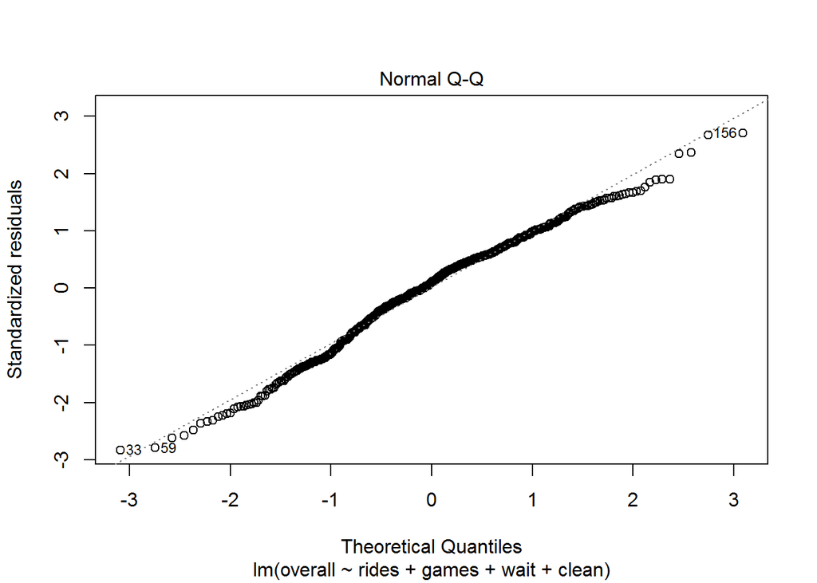

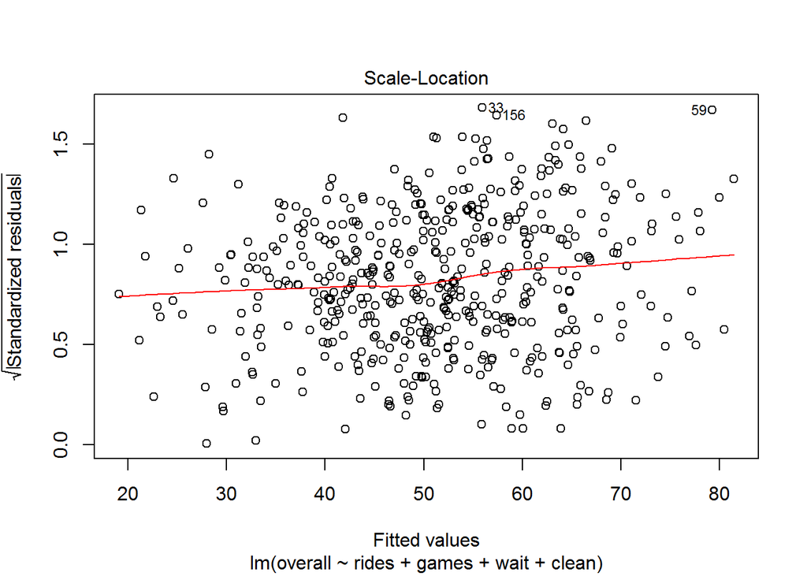

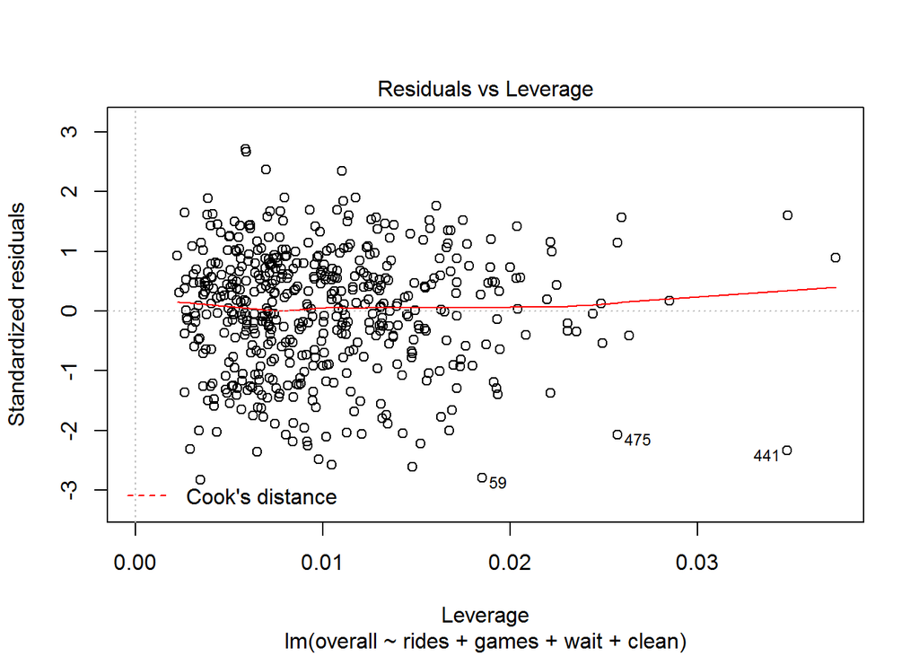

```r
plot(lm2)
```

- 예측

```r
test = sat.df[1:50,]
lm3 = lm(overall ~ rides*games, data=sat.df)
summary(lm3)
```

```
##
## Call:
## lm(formula = overall ~ rides * games, data = sat.df)
##
## Residuals:
##     Min      1Q  Median      3Q     Max
## -32.200  -9.356  -0.313   8.927  32.936
##
## Coefficients:
##               Estimate Std. Error t value Pr(>|t|)
## (Intercept) -56.011520  82.387884  -0.680    0.497
## rides         0.861823   0.964334   0.894    0.372
## games        -0.181435   1.039219  -0.175    0.861
## rides:games   0.007021   0.012079   0.581    0.561
##
## Residual standard error: 12.53 on 496 degrees of freedom
## Multiple R-squared:  0.3806, Adjusted R-squared:  0.3768
## F-statistic: 101.6 on 3 and 496 DF,  p-value: < 2.2e-16
```

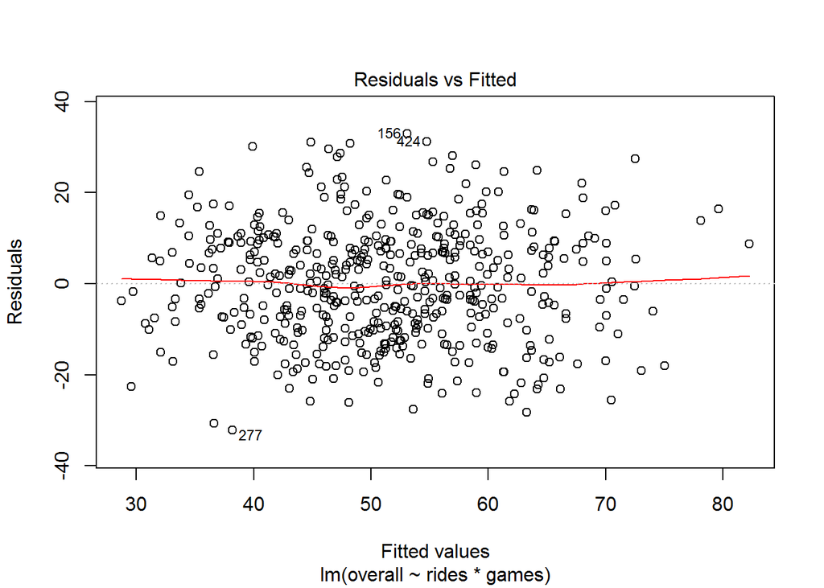

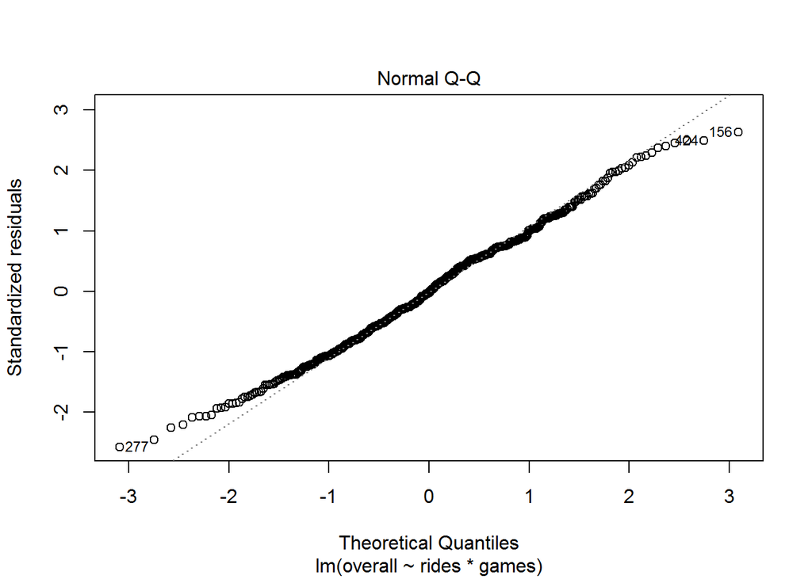

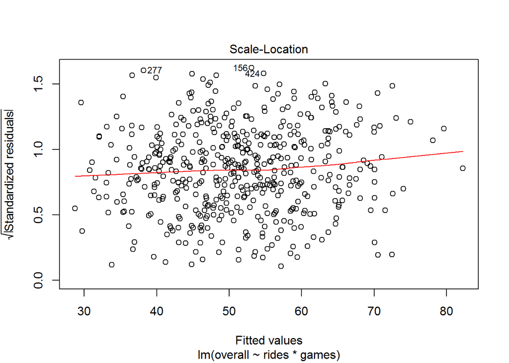

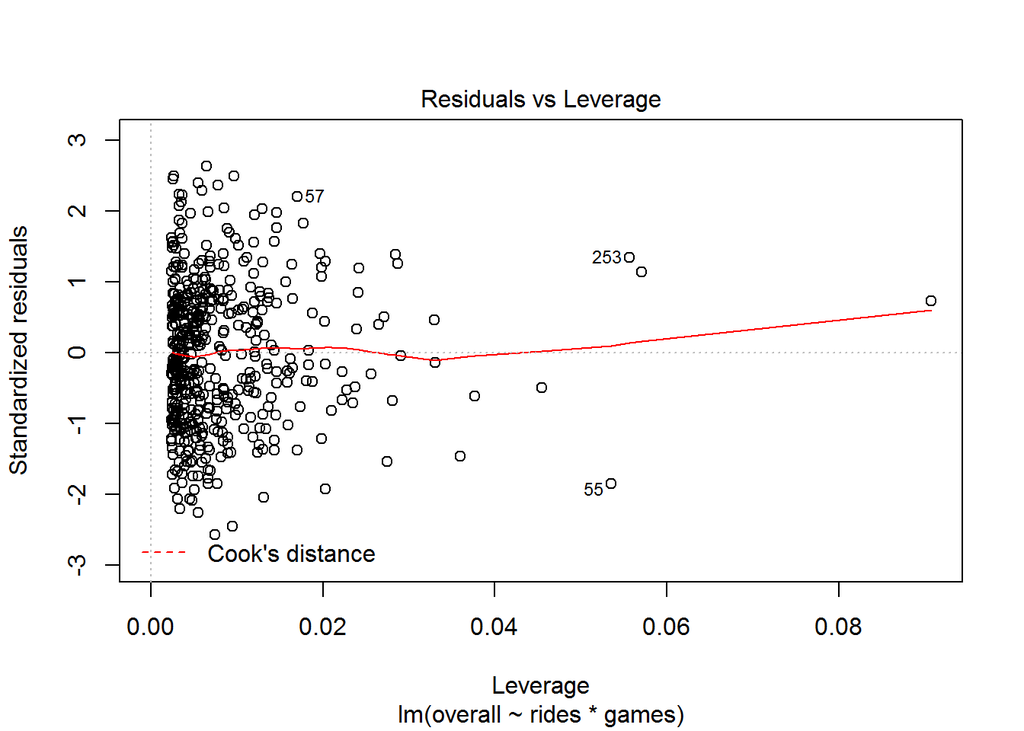

```r
plot(lm3)
```

```r
predict(lm3, test)
```

```
##        1        2        3        4        5        6        7        8
## 50.31527 52.46241 50.47420 51.25321 51.90920 44.39275 36.57142 42.26038
##        9       10       11       12       13       14       15       16
## 61.19581 57.36350 65.16337 38.94693 63.76459 48.65305 49.78570 56.05415
##       17       18       19       20       21       22       23       24
## 51.25321 43.61370 40.50945 57.05528 63.69069 49.45902 39.93402 59.01541
##       25       26       27       28       29       30       31       32
## 51.28498 57.18612 33.08388 41.83541 61.83255 54.85457 48.83115 35.20333
##       33       34       35       36       37       38       39       40
## 53.58736 42.67950 39.69344 56.05415 53.75069 59.93043 61.64630 66.15748
##       41       42       43       44       45       46       47       48
## 38.94693 44.49735 42.97624 48.23393 56.96661 40.06666 44.62631 42.84356
##       49       50
## 47.41721 52.17710
```

- 간략한 모델의 장점 : 오버피팅 방지, 설명력
- 모델생성 시 인수
- 전진추가(1개변인에서 시작), 후진소거(전체에서 1개씩 삭제) 방법사용

```r
lm2 = lm(overall ~ ., data=sat.df)
summary(lm2)
```

```
##
## Call:
## lm(formula = overall ~ ., data = sat.df)
##
## Residuals:
##      Min       1Q   Median       3Q      Max
## -23.4974  -6.2722   0.1008   6.4944  27.4919
##
## Coefficients:
##               Estimate Std. Error t value Pr(>|t|)
## (Intercept) -139.05182    7.31749 -19.003  < 2e-16 ***
## weekendyes    -0.77181    0.81057  -0.952  0.34147
## num.child      3.61824    0.26980  13.411  < 2e-16 ***
## distance       0.06391    0.02233   2.862  0.00438 **
## rides          0.60667    0.12118   5.007 7.74e-07 ***
## games          0.13796    0.05872   2.349  0.01920 *
## wait           0.56629    0.04067  13.924  < 2e-16 ***
## clean          0.93483    0.13614   6.867 1.99e-11 ***
## logdist       -0.76364    0.75295  -1.014  0.31099
## ---
## Signif. codes:  0 '***' 0.001 '**' 0.01 '*' 0.05 '.' 0.1 ' ' 1
##
## Residual standard error: 9 on 491 degrees of freedom
## Multiple R-squared:  0.6839, Adjusted R-squared:  0.6787
## F-statistic: 132.8 on 8 and 491 DF,  p-value: < 2.2e-16
```

```r
step(lm2, direction = "forward")
```

```
## Start:  AIC=2206.16
## overall ~ weekend + num.child + distance + rides + games + wait +
##     clean + logdist
```

```
##
## Call:
## lm(formula = overall ~ weekend + num.child + distance + rides +
##     games + wait + clean + logdist, data = sat.df)
##
## Coefficients:
## (Intercept)   weekendyes    num.child     distance        rides
##  -139.05182     -0.77181      3.61824      0.06391      0.60667
##       games         wait        clean      logdist
##     0.13796      0.56629      0.93483     -0.76364
```

```r
step(lm2, direction = "backward")
```

```
## Start:  AIC=2206.16
## overall ~ weekend + num.child + distance + rides + games + wait +
##     clean + logdist
##
##             Df Sum of Sq   RSS    AIC
## - weekend    1      73.4 39846 2205.1
## - logdist    1      83.3 39856 2205.2
## <none>                   39772 2206.2
## - games      1     447.1 40219 2209.8
## - distance   1     663.7 40436 2212.4
## - rides      1    2030.4 41803 2229.1
## - clean      1    3819.6 43592 2250.0
## - num.child  1   14568.0 54340 2360.2
## - wait       1   15705.7 55478 2370.6
##
## Step:  AIC=2205.08
## overall ~ num.child + distance + rides + games + wait + clean +
##     logdist
##
##             Df Sum of Sq   RSS    AIC
## - logdist    1      73.3 39919 2204.0
## <none>                   39846 2205.1
## - games      1     451.9 40298 2208.7
## - distance   1     655.7 40501 2211.2
## - rides      1    2066.5 41912 2228.4
## - clean      1    3804.6 43650 2248.7
## - num.child  1   14589.7 54435 2359.1
## - wait       1   15672.4 55518 2368.9
##
## Step:  AIC=2204
## overall ~ num.child + distance + rides + games + wait + clean
##
##             Df Sum of Sq   RSS    AIC
## <none>                   39919 2204.0
## - games      1     453.8 40373 2207.7
## - distance   1    1144.1 41063 2216.1
## - rides      1    2114.7 42034 2227.8
## - clean      1    3758.8 43678 2247.0
## - num.child  1   14572.7 54492 2357.6
## - wait       1   15615.7 55535 2367.1
```

```
##
## Call:
## lm(formula = overall ~ num.child + distance + rides + games +
##     wait + clean, data = sat.df)
##
## Coefficients:
## (Intercept)    num.child     distance        rides        games
##   -141.2306       3.6185       0.0457       0.6177       0.1390
##        wait        clean
##      0.5642       0.9259
```

```r
names(sat.df)
```

```
## [1] "weekend"   "num.child" "distance"  "rides"     "games"     "wait"
## [7] "clean"     "overall"   "logdist"
```

## 6. 로지스틱 회귀분석

- GLM은 정상분포가 아닌 변인들을 다룰 수 있다.
- GLM은 구매회수, 웹사이트 방문시간, yes/no와 같은 변인을 다룬다.
- GLM의 일반적 특징은 정규분포된 예측치로 비정규분포의 결과물을 산출
- 놀이공원 데이터 : 시즌티켓 구매여부가 포함된 데이터임
- 2가지 변인에 기초함 - 프로모션채널
- 마케터는 어떻게 프로모션을 고객의 구매를 촉진하는지 궁금하다.
- data 로딩

```r
pass.df <- read.csv("http://goo.gl/J8MH6A")
summary(pass.df)
```

```
##   Channel          Promo           Pass
##  Email: 633   Bundle  :1674   NoPass :1567
##  Mail :1328   NoBundle:1482   YesPass:1589
##  Park :1195
```

```r
str(pass.df)
```

```
## 'data.frame':    3156 obs. of  3 variables:
##  $ Channel: Factor w/ 3 levels "Email","Mail",..: 2 2 2 2 2 2 2 2 2 2 ...
##  $ Promo  : Factor w/ 2 levels "Bundle","NoBundle": 1 1 1 1 1 1 1 1 1 1 ...
##  $ Pass   : Factor w/ 2 levels "NoPass","YesPass": 2 2 2 2 2 2 2 2 2 2 ...
```

```r
head(pass.df)
```

```
##   Channel  Promo    Pass
## 1    Mail Bundle YesPass
## 2    Mail Bundle YesPass
## 3    Mail Bundle YesPass
## 4    Mail Bundle YesPass
## 5    Mail Bundle YesPass
## 6    Mail Bundle YesPass
```

- 모델생성
- coefficient : 0.3888
- p밸류 : 5.81e-08 (번들은 시즌권 판매에 유의한 영향을 미쳤음)

```r
pass.m1 <- glm(Pass ~ Promo, data=pass.df, family=binomial)
summary(pass.m1)
```

```
##
## Call:
## glm(formula = Pass ~ Promo, family = binomial, data = pass.df)
##
## Deviance Residuals:
##    Min      1Q  Median      3Q     Max
## -1.262  -1.097   1.095   1.095   1.260
##
## Coefficients:
##               Estimate Std. Error z value Pr(>|z|)
## (Intercept)    0.19657    0.04912   4.002 6.28e-05 ***
## PromoNoBundle -0.38879    0.07167  -5.425 5.81e-08 ***
## ---
## Signif. codes:  0 '***' 0.001 '**' 0.01 '*' 0.05 '.' 0.1 ' ' 1
##
## (Dispersion parameter for binomial family taken to be 1)
##
##     Null deviance: 4375.0  on 3155  degrees of freedom
## Residual deviance: 4345.4  on 3154  degrees of freedom
## AIC: 4349.4
##
## Number of Fisher Scoring iterations: 3
```

- 회귀계수에 exp함수 적용시 oods비(성공/안성공 비율)
- 이는 번들제공시 시즌권을 살 확률이 47%증가했음을 의미

```r
exp(0.3888)
```

```
## [1] 1.475209
```

- 채널을 넣어서 다시 GLM돌려보자
- 프로모션은 강하게 부정적인 기여를 한다.

```r
pass.m2 <- glm(Pass ~ Promo + Channel, data=pass.df, family=binomial)
summary(pass.m2)
```

```
##
## Call:
## glm(formula = Pass ~ Promo + Channel, family = binomial, data = pass.df)
##
## Deviance Residuals:
##     Min       1Q   Median       3Q      Max
## -1.9079  -0.9883   0.5946   0.7637   2.3272
##
## Coefficients:
##               Estimate Std. Error z value Pr(>|z|)
## (Intercept)   -2.63882    0.15290 -17.258  < 2e-16 ***
## PromoNoBundle  0.56022    0.09031   6.203 5.54e-10 ***
## ChannelMail    2.17617    0.14651  14.854  < 2e-16 ***
## ChannelPark    3.72176    0.15964  23.313  < 2e-16 ***
## ---
## Signif. codes:  0 '***' 0.001 '**' 0.01 '*' 0.05 '.' 0.1 ' ' 1
##
## (Dispersion parameter for binomial family taken to be 1)
##
##     Null deviance: 4375.0  on 3155  degrees of freedom
## Residual deviance: 3490.2  on 3152  degrees of freedom
## AIC: 3498.2
##
## Number of Fisher Scoring iterations: 4
```

- compute the odds ratios and confidence intervals
- 번들프로모션은 32–53 % 구매확률을 낮추는것과 관련된다.
- 공원에서 판매는 30~56으로 더 높아졌다.

```r
exp(coef(pass.m2))
```

```
##   (Intercept) PromoNoBundle   ChannelMail   ChannelPark
##    0.07144576    1.75105418    8.81250655   41.33712060
```

```r
exp(confint(pass.m2))
```

```
##                     2.5 %      97.5 %
## (Intercept)    0.05255011  0.09575698
## PromoNoBundle  1.46839683  2.09231422
## ChannelMail    6.65770550 11.83281727
## ChannelPark   30.42959274 56.92953688
```

- 이를 적절한 모델이라고 할수 있는가?
- 번들플모션은 채널에 의해 차별적으로 영향을 미친다.
- 번들-이메일간에 극적인 차이를 보이므로 상호작용효과를 보자.

```r
pass.m3 <- glm(Pass ~ Promo + Channel + Promo:Channel,
               data=pass.df, family=binomial)
summary(pass.m3)
```

```
##
## Call:
## glm(formula = Pass ~ Promo + Channel + Promo:Channel, family = binomial,
##     data = pass.df)
##
## Deviance Residuals:
##     Min       1Q   Median       3Q      Max
## -1.9577  -0.9286   0.5642   0.7738   2.4259
##
## Coefficients:
##                           Estimate Std. Error z value Pr(>|z|)
## (Intercept)                -0.7813     0.1959  -3.989 6.64e-05 ***
## PromoNoBundle              -2.1071     0.2783  -7.571 3.71e-14 ***
## ChannelMail                 0.1632     0.2115   0.772     0.44
## ChannelPark                 1.8340     0.2107   8.702  < 2e-16 ***
## PromoNoBundle:ChannelMail   2.9808     0.3003   9.925  < 2e-16 ***
## PromoNoBundle:ChannelPark   2.8115     0.3278   8.577  < 2e-16 ***
## ---
## Signif. codes:  0 '***' 0.001 '**' 0.01 '*' 0.05 '.' 0.1 ' ' 1
##
## (Dispersion parameter for binomial family taken to be 1)
##
##     Null deviance: 4375.0  on 3155  degrees of freedom
## Residual deviance: 3393.5  on 3150  degrees of freedom
## AIC: 3405.5
##
## Number of Fisher Scoring iterations: 5
```

## 7. 군집분석

- 소속집단을 알고 있는 데이터를 이용해 분류(분류분석-supervised learning)
- 소속집단을 모르는 데이터를 동질집단을 분류(군집분석-unsupervised learning)
- 데이터들의 유사성과 관련성을 근거로 군집을 형성
- 군집 내 유사성이 높을수록 좋고 군집간 차이가 클수록 좋음

```r
x1<-c(1,2,4,4,5)
x2<-c(5,4,6,3,3)
hcdata<-data.frame(x1,x2)
hcdata
```

```
##   x1 x2
## 1  1  5
## 2  2  4
## 3  4  6
## 4  4  3
## 5  5  3
```

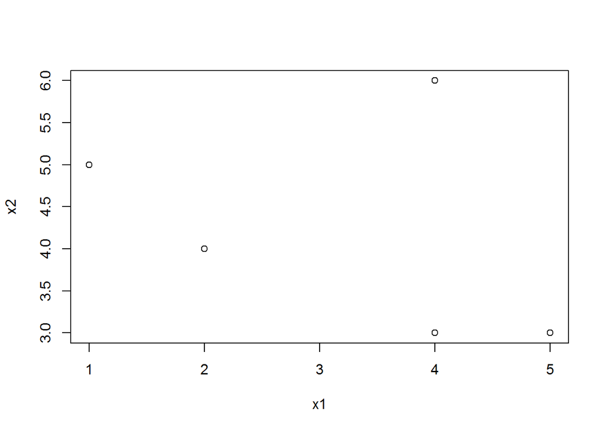

```r
plot(hcdata)
```

- hcluster

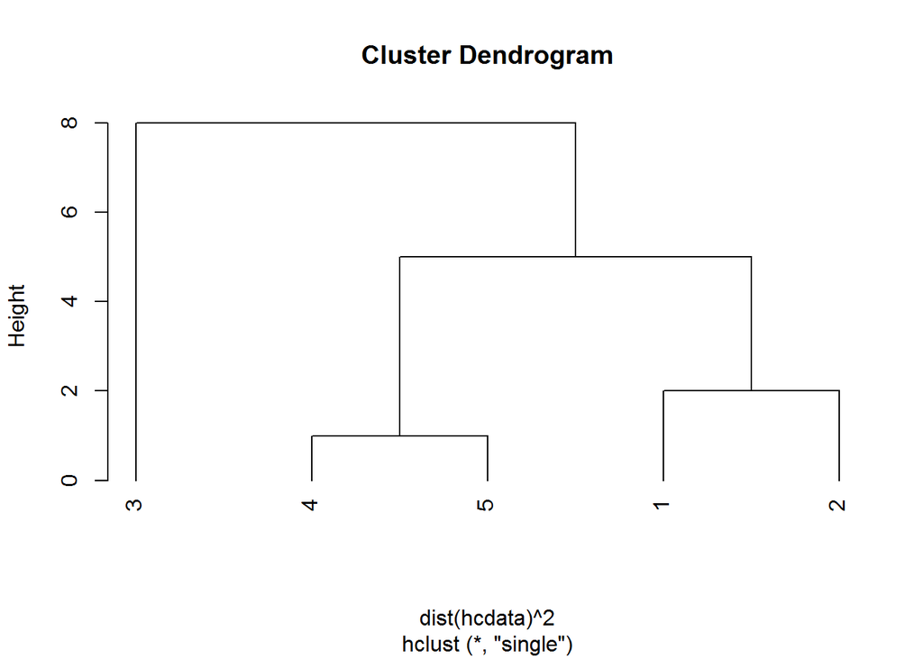

```r
hcl<-hclust(dist(hcdata)^2, method='single')
plot(hcl, hang=-1)
```

- Kmeans

```r
newiris <- iris
newiris$Species <- NULL
kc <- kmeans(newiris, 3)
kc
```

```
## K-means clustering with 3 clusters of sizes 38, 62, 50
##
## Cluster means:
##   Sepal.Length Sepal.Width Petal.Length Petal.Width
## 1     6.850000    3.073684     5.742105    2.071053
## 2     5.901613    2.748387     4.393548    1.433871
## 3     5.006000    3.428000     1.462000    0.246000
##
## Clustering vector:
##   [1] 3 3 3 3 3 3 3 3 3 3 3 3 3 3 3 3 3 3 3 3 3 3 3 3 3 3 3 3 3 3 3 3 3 3 3
##  [36] 3 3 3 3 3 3 3 3 3 3 3 3 3 3 3 2 2 1 2 2 2 2 2 2 2 2 2 2 2 2 2 2 2 2 2
##  [71] 2 2 2 2 2 2 2 1 2 2 2 2 2 2 2 2 2 2 2 2 2 2 2 2 2 2 2 2 2 2 1 2 1 1 1
## [106] 1 2 1 1 1 1 1 1 2 2 1 1 1 1 2 1 2 1 2 1 1 2 2 1 1 1 1 1 2 1 1 1 1 2 1
## [141] 1 1 2 1 1 1 2 1 1 2
##
## Within cluster sum of squares by cluster:
## [1] 23.87947 39.82097 15.15100
##  (between_SS / total_SS =  88.4 %)
##
## Available components:
##
## [1] "cluster"      "centers"      "totss"        "withinss"
## [5] "tot.withinss" "betweenss"    "size"         "iter"
## [9] "ifault"
```

```r
table(iris$Species, kc$cluster)
```

```
##
##               1  2  3
##   setosa      0  0 50
##   versicolor  2 48  0
##   virginica  36 14  0
```

## 8. 분류분석

- 소속집단을 알고 있는 데이터들을 바탕으로 분류알고리즘을 만듬
- 데이터셋을 둘로 나누어 알고리즘이 잘 작동하는지 교차검증

```r
data(iris)
names(iris)
```

```
## [1] "Sepal.Length" "Sepal.Width"  "Petal.Length" "Petal.Width"
## [5] "Species"
```

```r
#"Sepal.Length" "Sepal.Width"  "Petal.Length" "Petal.Width"  "Species"
table(iris$Species)
```

```
##
##     setosa versicolor  virginica
##         50         50         50
```

- 데이터셋 생성

```r
library(caret)
inTrain = createDataPartition(y=iris$Species,
                              p=0.7,
                              list=FALSE)

training = iris[inTrain,]
testing = iris[-inTrain,]
```

- Petal.Width, Sepal.Width 플랏 시각화

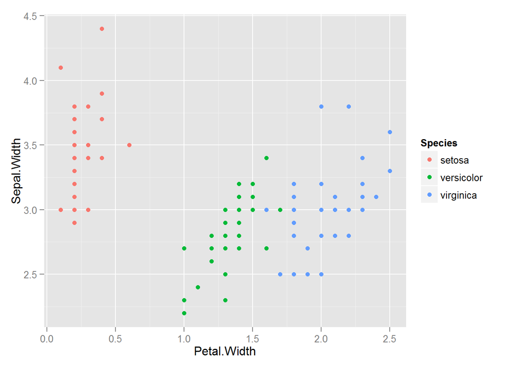

```r
qplot(Petal.Width, Sepal.Width,
      colour=Species,
      data=training)
```

- 모델생성

```r
modfit = train(Species~.,
               method="rpart",
               data=training)
```

- 트리 시각화

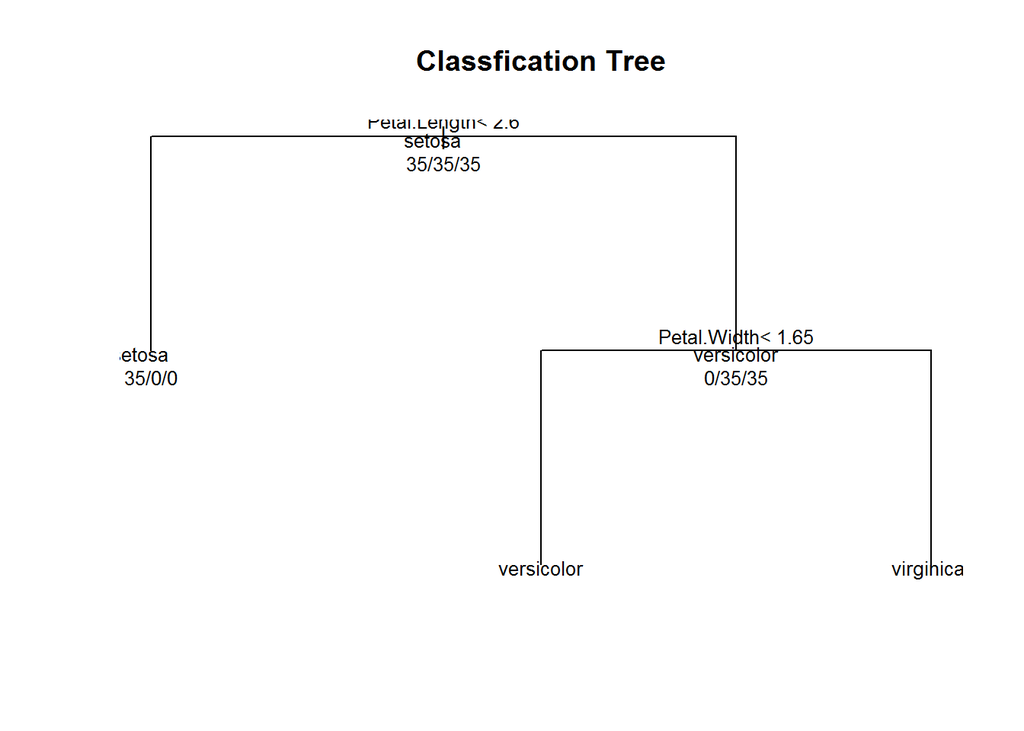

```r
plot(modfit$finalModel,
     uniform=TRUE,
     main="Classfication Tree")

text(modfit$finalModel,
     use.n=TRUE,
     all=TRUE,
     cex=0.8)
```

- 트리 예쁘게 시각화

```r
library(rattle)
```

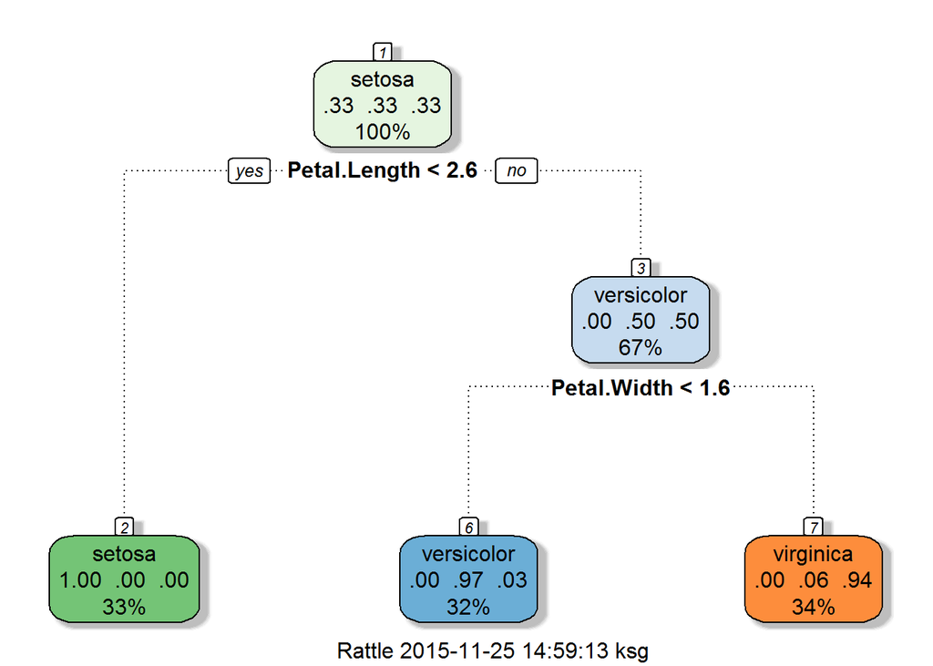

```r
fancyRpartPlot(modfit$finalModel)
```

- 테스트 데이터로 모델 검증

```r
predict(modfit, newdata = testing)
```

```
##  [1] setosa     setosa     setosa     setosa     setosa     setosa
##  [7] setosa     setosa     setosa     setosa     setosa     setosa
## [13] setosa     setosa     setosa     versicolor versicolor versicolor
## [19] versicolor versicolor versicolor versicolor versicolor versicolor
## [25] versicolor versicolor versicolor versicolor versicolor versicolor
## [31] virginica  virginica  virginica  virginica  virginica  versicolor
## [37] virginica  virginica  virginica  versicolor versicolor virginica
## [43] virginica  virginica  virginica
## Levels: setosa versicolor virginica
```